# Fine-scale mapping of savanna physiognomic types

Mapping major land cover types using Random Forest (level 1 classification)

Fernanda Ribeiro

June 1, 2020

## Pre-processing

### Defining land cover classes

The land cover classes were defined based on the Land Cover Classification System (LCCS) from the Food and Agriculture Organization (FAO), adapted to the RapidEye imagery specs: 1) closed-canopy trees, 2) open canopy trees, 3) dense shrub, 4) open shrub, 5) scrub-shrub, 6) shrub-herb, 7) herbaceous (invasive), 8) herbaceous (dry), 9) herbaceous (wet), 10) soil, NPV, impervious surfaces (bright), 11) soil, NPV, impervious surfaces (dark), 12) water/shade

### Imagery acquisition & pre-processing steps

The RapidEye tiles were acquired from the Brazilian Ministry of the Environment (MMA) imagery repository; 1 tile was collected for the Taquara site (2013, dry season) and 16 tiles were collected for the Western Bahia site (2011, dry season). Atmospheric correction and reflectance retrieval of all individual imagery tiles were performed using ACORN 4.0 software.

### **Level 1 Classification**

*Using the Random Forest algorithm to map major land cover types*

```r
# Setup workspace
setwd("/Users/fernandaribeiro/Documents/ribeiro2020_repo/level1_classif/taq_data")

# Load libraries
library(rgdal)
library(foreign)
library(randomForest)
library(dplyr)
```

```r
library(ggplot2)
```

### Image Segmentation

Often in land cover classification, we use raster imagery to predict a map based on a classification model using an algorithm of choice. In GEOBIA, we use a shapefile of image objects (a.k.a. polygons derived from image segmentation) to predict our map.

#### *Deriving spectral variables (e.g. statistics and indices)*

Spectral variables (object features) were derived to be used as inputs in the land cover classification model. We derived the following spectral variables for all individual image objects covering the entire extent of the imagery: a) brightness, b) mean reflectance value of each spectral band, c) standard deviation reflectance value of each spectral band, d) Indices (NDVI, NDVI – red-edge, NDWI)

The image objects generated in the segmentation (along with derived spectral variables) were exported to a shapefile, which will be used to predict our Level 1 classification map. Now, let’s import it into R:

```r
# Importing objects covering the entire extent of the imagery

all_obj <- read.dbf("taq_all_obj_v10.dbf") #reads .dbf table from a shp containing all polygons generated in the image segmentation
```

### Training data collection

```r
# Importing training data

training_obj <- read.dbf("taq_training_v10.dbf") #reads training data .dbf table
```

#### **IMPORTANT!**

Before moving forward, make sure that both shapefiles (‘all_obj’ & ‘training_obj’) have a shared ID column. This will be crucial in further steps!

```r
head(training_obj, 3)
```

```
##   brightness        classes  mean_b1  mean_b2  mean_b3   mean_b4  mean_b5
## 1   398.5836     open_shrub 156.1286 394.6500 640.9500  989.9786 1512.600
## 2   354.4042 herbaceous_dry 130.4831 346.9492 570.4322  894.4407 1370.161
## 3   406.5935     open_shrub 143.4239 384.9130 638.8587 1015.1739 1586.283
##        NDVI   NDVIred      NDWI stdev_b1 stdev_b2 stdev_b3 stdev_b4 stdev_b5
## 1 0.4047503 0.2140060 0.5861581 23.51955 27.13167 43.05932 32.95743 39.82924
## 2 0.4121053 0.2211854 0.5958918 14.43732 15.27369 20.37799 22.21030 27.51578
## 3 0.4257815 0.2275138 0.6094624 27.40764 27.48504 46.51100 34.79524 45.14550
##    id
## 1 207
## 2 220
## 3 248
```

```r
head(all_obj, 3)
```

```
##   brightness      classes  mean_b1  mean_b2   mean_b3  mean_b4  mean_b5
## 1   525.8545 unclassified 145.9091 461.6364  618.8182 1204.091 2398.091
## 2   637.0000 unclassified 334.7500 717.2500 1146.7500 1452.250 2087.625
## 3   626.3600 unclassified 230.9333 582.6000  994.1000 1458.867 2414.533
##        NDVI   NDVIred      NDWI stdev_b1 stdev_b2  stdev_b3  stdev_b4  stdev_b5
## 1 0.5897668 0.3210652 0.6771466 47.68353 72.64018  82.09841  95.93696 111.91511
## 2 0.2908986 0.1175452 0.4885690 32.38344 20.16649  37.60236  31.94037  42.43801
## 3 0.4167164 0.1894713 0.6112285 61.65005 94.29054 131.90359 119.92657 137.14827
##   id
## 1  1
## 2  2
## 3  3
```

# Random Forest model

All training samples were used as inputs in a random forest (RF) model to map the major land cover types defined. The model accounts for all spectral variables derived in the previous (image segmentation) step.

```r
# Creating Random Forest classification model
model_rf <- randomForest(classes ~ brightness + mean_b1 + mean_b2 + mean_b3 + mean_b4 + mean_b5 + NDVI + NDVIred + NDWI + stdev_b1 + stdev_b2 + stdev_b3 + stdev_b4 + stdev_b5, data = training_obj, importance = TRUE, progress='text')
```

We can now visualize the result of our RF model and the importance of each band (spectral variable) used in the model:

```r
print(model_rf) # shows RF model
```

```
##
## Call:
##  randomForest(formula = classes ~ brightness + mean_b1 + mean_b2 +      mean_b3 + mean_b4 + mean_b5 + NDVI + NDVIred + NDWI + stdev_b1 +      stdev_b2 + stdev_b3 + stdev_b4 + stdev_b5, data = training_obj,      importance = TRUE, progress = "text")
##                Type of random forest: classification
##                      Number of trees: 500
## No. of variables tried at each split: 3
##
##         OOB estimate of  error rate: 7.81%
## Confusion matrix:
##                     closed_canopy dense_shrub herbaceous herbaceous_dry
## closed_canopy                 121           0          0              0
## dense_shrub                     0         125          0              0
## herbaceous                      0           0         35              0
## herbaceous_dry                  0           0          0             38
## herbaceous_wet                  0           1          0              0
## open_canopy                     7           4          0              0
## open_shrub                      0           2          0              5
## soil_NPV_imp_bright             0           0          0              0
## soil_NPV_imp_dark               0           0          0              0
##                     herbaceous_wet open_canopy open_shrub soil_NPV_imp_bright
## closed_canopy                    0           5          1                   1
## dense_shrub                      0           1          1                   0
## herbaceous                       0           0          0                   0
## herbaceous_dry                   0           0          8                   0
## herbaceous_wet                   9           2          2                   0
## open_canopy                      0          31          0                   1
## open_shrub                       0           0        114                   0
## soil_NPV_imp_bright              0           0          0                 150
## soil_NPV_imp_dark                0           1          2                   4
##                     soil_NPV_imp_dark class.error
## closed_canopy                       0  0.05468750
## dense_shrub                         1  0.02343750
## herbaceous                          0  0.00000000
## herbaceous_dry                      0  0.17391304
## herbaceous_wet                      1  0.40000000
## open_canopy                         1  0.29545455
## open_shrub                          5  0.09523810
## soil_NPV_imp_bright                 6  0.03846154
## soil_NPV_imp_dark                 109  0.06034483
```

#### *Checking out-of-bag (OOB) error estimates*

Random Forest generates an out-of-bag (OOB) error estimate using subsampling and bootstrapping, accounting for samples not used to train the model. The OOB error for the Taquara site was 7.8% (thus, 92.2% overall accuracy). However, the OOB error is subject to spatial autocorrelation, which can generate inflated estimates and should be used with caution. Best practices to evaluate accuracy of thematic maps recommend additional independent validation.

```r
importance(model_rf) # displays importance of each band used in the model
```

```
##            closed_canopy dense_shrub herbaceous herbaceous_dry herbaceous_wet
## brightness     14.112372   11.695030 15.4271309      14.763168     6.31230836
## mean_b1        12.131113   10.934293  4.2949038      10.435963     2.71293629
## mean_b2        13.905349   13.315908 12.6725114      14.626226     5.89478994
## mean_b3        17.858728   19.670229 13.0451428      14.998778     6.52283188
## mean_b4        15.239205   15.485257 14.9160466      16.290382     6.94630825
## mean_b5        10.634901   12.650402 15.5400476      23.791020     7.82336078
## NDVI           15.997576   23.927497 17.7912221      22.060406    10.22059210
## NDVIred        15.991322   20.144468 19.2634865      21.252040     8.30670301
## NDWI           15.834256   15.502239 15.9772221      20.413354     4.95877357
## stdev_b1        7.815065    9.889713  0.3198584       1.386434     1.42831413
## stdev_b2       12.617006    9.690106  5.1613673      10.798100     1.02186345
## stdev_b3       10.348237    9.142917  6.4264163      14.852905    -1.51880646
## stdev_b4       12.161279   14.641977  5.0165756       9.351611    -0.06819311
## stdev_b5       17.445526   19.660542 14.0320968       9.823566     4.12325046
##            open_canopy open_shrub soil_NPV_imp_bright soil_NPV_imp_dark
## brightness   13.675756  15.710913           11.324989         17.569732
## mean_b1      11.994490  11.907226            6.056520         11.155157
## mean_b2      14.488479  14.807463           11.385318         14.042334
## mean_b3      14.192883  18.408877           17.787541         20.476964
## mean_b4      12.904234  20.697622           13.006016         19.643989
## mean_b5       9.841821  17.649131            8.786106         18.490009
## NDVI         19.625761  27.505095           21.786850         19.758683
## NDVIred      15.780747  22.822148           24.598422         19.745263
## NDWI         20.888529  18.071917           12.797169         17.103592
## stdev_b1      6.049697   7.382517            5.009126          3.845159
## stdev_b2      5.773472  10.436884           10.220841          9.374320
## stdev_b3      5.191783  22.758500           12.543598         27.388053
## stdev_b4      7.269972  16.626552           13.610052         17.291199
## stdev_b5      2.719484  13.958093           12.013912         18.639167
##            MeanDecreaseAccuracy MeanDecreaseGini
## brightness             24.15569         40.21325
## mean_b1                20.62994         31.48838
## mean_b2                23.43072         44.56936
## mean_b3                29.99028         68.23198
## mean_b4                27.07511         48.95387
## mean_b5                33.00084         50.53339
## NDVI                   31.24035         86.01098
## NDVIred                29.96001         90.65072
## NDWI                   23.22554         56.95388
## stdev_b1               15.40739         11.27923
## stdev_b2               20.69223         27.10575
## stdev_b3               32.62864         31.74251
## stdev_b4               27.17250         36.84448
## stdev_b5               25.26132         52.81762
```

We can now use our RF model to predict our Level 1 classification

```r
# Predict land cover classification (level 1) based on RF model
# For this step, make sure that "all_obj" shp has an ID column

pred_rf <- predict(model_rf, all_obj, type='response', overwrite=TRUE, progress='text')
```

Notice that our predictions (pred_rf) file is in a *factor* format. The next step is to convert *predictions* into a shapefile

```r
## step 1. Transform pred_rf (factor format) to dataframe
predictions <- as.data.frame(pred_rf) #transform to dataframe

## step 2. create ID for predictions
id <- rownames(predictions) #create an ID vector
id_pred <- cbind(id=id, predictions) #create an ID column to 'predictions'
#names(d) <- c('id', 'pred_rf')  #rename columns if needed
#names(d) #check column names
#
```

Let’s import the shapefile containing all image objects derived for the whole imagery

```r
## Read all segments shapefile

library(sf)
all_segs <- st_read("taq_all_obj_v10.shp", layer="taq_all_obj_v10") #reads shapefile
```

#### *Important Notice*

The “all objects” shapefile must contain the following columns: **id**, where there’s a unique ID for each polygon, and **class name** (this can contain the actual class names or a code for each class name);

Now, we can convert our predictions dataframe into a shapefile

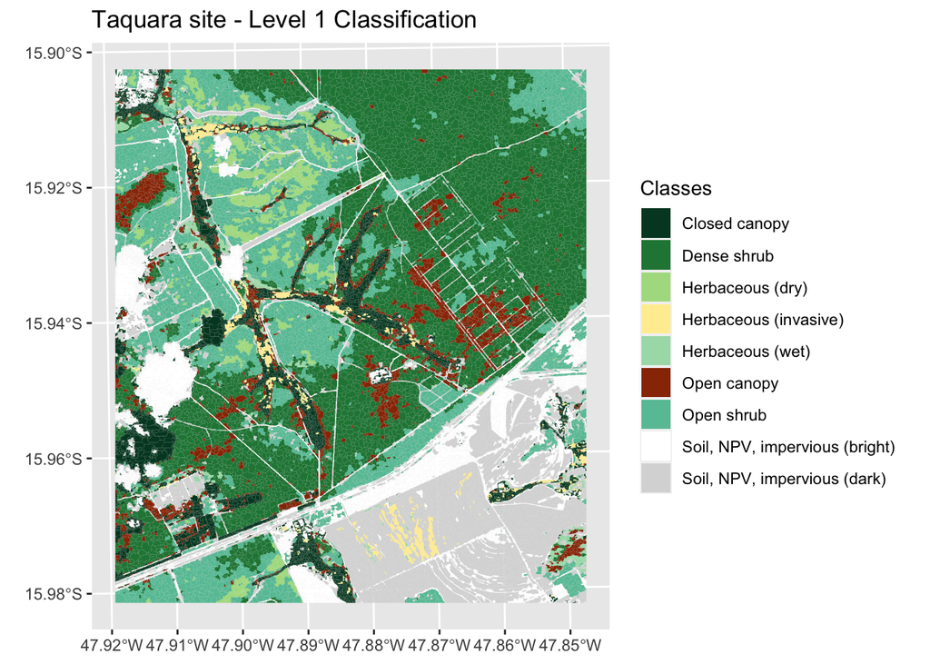

```r
## Merge predictions and all segments shapefile by ID
predVals <- merge(all_segs, id_pred, by="id") #merge "all segments" shapefile with "d" (predictions with id)

## Export predictions to a shapefile
#writeOGR(obj=predVals, dsn = '.', layer="taq_level1_classif", driver="ESRI Shapefile")

## Plot final classification
predVals$pred_rf <- as.character(predVals$pred_rf)
predVals$pred_rf[predVals$pred_rf=="closed_canopy"]<-"Closed canopy"
predVals$pred_rf[predVals$pred_rf=="dense_shrub"]<-"Dense shrub"
predVals$pred_rf[predVals$pred_rf=="herbaceous"]<-"Herbaceous (invasive)"
predVals$pred_rf[predVals$pred_rf=="herbaceous_dry"]<-"Herbaceous (dry)"
predVals$pred_rf[predVals$pred_rf=="herbaceous_wet"]<-"Herbaceous (wet)"
predVals$pred_rf[predVals$pred_rf=="open_canopy"]<-"Open canopy"
predVals$pred_rf[predVals$pred_rf=="open_shrub"]<-"Open shrub"
predVals$pred_rf[predVals$pred_rf=="soil_NPV_imp_bright"]<-"Soil, NPV, impervious (bright)"
predVals$pred_rf[predVals$pred_rf=="soil_NPV_imp_dark"]<-"Soil, NPV, impervious (dark)"


classCol <- c("#004529", "#238443", "#addd8e",
              "#ffeda0", "#a8ddb5", "#993404",
              "#66c2a4", "#ffffff", "#d9d9d9")

map <- ggplot() + geom_sf(data = predVals, aes(fill = factor(pred_rf)), color = NA) +
      scale_fill_manual(name = "Classes", values = classCol) +
      ggtitle("Taquara site - Level 1 Classification") +
      coord_sf()
map
```

This step concludes the “Level 1 Classification” of the GEOBIA Framework. For additional details, please check Ribeiro et al. (2020) or contact the corresponding author (contact: fernanda.ffr@gmail.com)